# EDA of Affan_nonAFP

mcc

6/11/2020

# This is Rmarkdown file shows the preliminary Exploratory Data Analysis for the ‘Affan_nonAFP_r9493c840_original_twoSeg_AACandDipeptide.csv’ data found at https://www.kaggle.com/rafay12/anti-freeze-protein-classification/metadata.

The file size is: 25 MB.

NOTE 1: The dataset does not appear to have column names as the first row.

NOTE 2: The first column contains **Alpha-numerics** and there **May** appear to be some **Underscores** sprinkled about. Check this out.

NOTE 3: Columns x3-x22 appear to have values #.### format while columns x23-x842 appear as 0.### or 1.### values.

Is Setup:

Column1 - Protein ID Column 2 - 0 indicates control set(?) Columns x3-x22 - Amino acid percent Composistion(AAC) Columns x23-x842 - Dipeptide Composition

# Import libraries, NO “doMC”,

Load Data: ‘Affan_nonAFP_r9493c840_original_twoSeg_AACandDipeptide.csv’

```r
Affan_nonAFP <- read_csv("Affan_nonAFP_r9493c840_original_twoSeg_AACandDipeptide.csv",
                         col_names = FALSE)
```

Check Affan_nonAFP dataframe dimensions

```r
dim(Affan_nonAFP)
```

```
## [1] 9493  842
```

Check RAW for missing values

```r
apply(is.na(Affan_nonAFP), 2, which)
```

```
## integer(0)
```

Note 4: No missing values indicated.

Numerical summary of COLUMNS x2-x22 of Affan_nonAFP data

```r
# Subset out columns 2 through 22 for first summary
aac <- Affan_nonAFP[c(2:22)]
summary(aac)
```

```
##        X2          X3               X4               X5
##  Min.   :0   Min.   : 0.000   Min.   : 0.000   Min.   : 0.000
##  1st Qu.:0   1st Qu.: 5.231   1st Qu.: 0.000   1st Qu.: 3.614
##  Median :0   Median : 7.463   Median : 1.034   Median : 5.236
##  Mean   :0   Mean   : 8.138   Mean   : 1.498   Mean   : 5.283
##  3rd Qu.:0   3rd Qu.:10.345   3rd Qu.: 2.062   3rd Qu.: 6.742
##  Max.   :0   Max.   :40.769   Max.   :28.125   Max.   :25.636
##        X6               X7               X8               X9
##  Min.   : 0.000   Min.   : 0.000   Min.   : 0.000   Min.   : 0.000
##  1st Qu.: 4.211   1st Qu.: 2.439   1st Qu.: 4.167   1st Qu.: 1.042
##  Median : 6.173   Median : 3.774   Median : 6.122   Median : 1.964
##  Mean   : 6.482   Mean   : 4.047   Mean   : 6.418   Mean   : 2.176
##  3rd Qu.: 8.333   3rd Qu.: 5.333   3rd Qu.: 8.235   3rd Qu.: 3.000
##  Max.   :41.176   Max.   :20.000   Max.   :45.714   Max.   :43.077
##       X10              X11              X12              X13
##  Min.   : 0.000   Min.   : 0.000   Min.   : 0.000   Min.   : 0.000
##  1st Qu.: 3.593   1st Qu.: 3.158   1st Qu.: 7.377   1st Qu.: 1.636
##  Median : 5.357   Median : 5.381   Median : 9.524   Median : 2.434
##  Mean   : 5.742   Mean   : 5.780   Mean   : 9.810   Mean   : 2.796
##  3rd Qu.: 7.407   3rd Qu.: 7.813   3rd Qu.:11.940   3rd Qu.: 3.529
##  Max.   :28.205   Max.   :37.500   Max.   :38.776   Max.   :29.213
##       X14              X15              X16              X17
##  Min.   : 0.000   Min.   : 0.000   Min.   : 0.000   Min.   : 0.000
##  1st Qu.: 2.381   1st Qu.: 2.941   1st Qu.: 2.315   1st Qu.: 3.323
##  Median : 3.846   Median : 4.425   Median : 3.609   Median : 5.128
##  Mean   : 4.200   Mean   : 4.822   Mean   : 3.971   Mean   : 5.434
##  3rd Qu.: 5.556   3rd Qu.: 6.183   3rd Qu.: 5.128   3rd Qu.: 7.143
##  Max.   :36.810   Max.   :69.231   Max.   :32.376   Max.   :48.000
##       X18              X19              X20              X21
##  Min.   : 0.000   Min.   : 0.000   Min.   : 0.000   Min.   : 0.000
##  1st Qu.: 4.895   1st Qu.: 3.806   1st Qu.: 4.678   1st Qu.: 0.000
##  Median : 6.731   Median : 5.274   Median : 6.289   Median : 0.958
##  Mean   : 7.117   Mean   : 5.490   Mean   : 6.548   Mean   : 1.229
##  3rd Qu.: 8.914   3rd Qu.: 6.818   3rd Qu.: 8.081   3rd Qu.: 1.835
##  Max.   :41.494   Max.   :46.420   Max.   :33.333   Max.   :12.500
##       X22
##  Min.   : 0.000
##  1st Qu.: 1.639
##  Median : 2.781
##  Mean   : 3.020
##  3rd Qu.: 4.149
##  Max.   :18.571
```

Boxplots: COLUMNS x2-x22 of Affan_nonAFP data

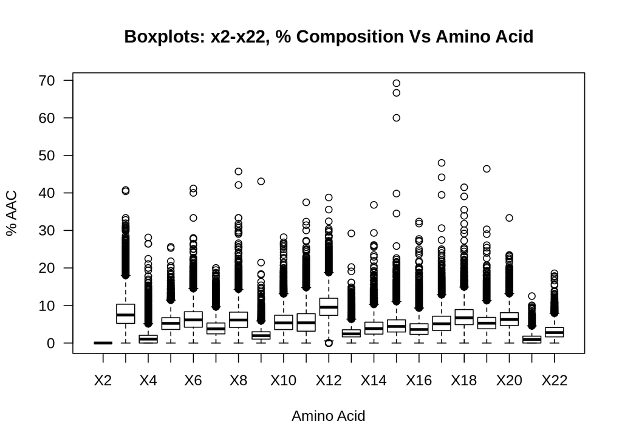

```r
boxplot(aac,
        main = "Boxplots: x2-x22, % Composition Vs Amino Acid",
        ylab = "% AAC",
        xlab = "Amino Acid",
        las = 1)
```

Q. Is {x4, x9, x21} a member of {cysteine, tyrosine, and tryptophan} ?

Inspection of Columns, x23 to x842

Note: Columns x23 to x423 may be dipeptides, since 20 x 20 = 400.

Other measures may include but not limited to:

[output not shown]

```r
aac <- Affan_nonAFP[c(23:842)]

variance_di_peptides <- sapply(aac, var)
length(variance_di_peptides)
```

```
## [1] 820
```

```r
# test columns for zero variance
# for (i in 23:842) {
#     if (variance_di_peptides[i] = 0) {
#
#     }
#
#
# }
```

[^1]: Hong-Bin Shen and Kuo-Chen Chou. PseAAC: a flexible web-server for generating various kinds of protein pseudo amino acid composition. Analytical Biochemistry, 2008, 373: 386-388